# Human Activity Recognition - Machine Learning Project

Ronaldo A Oliveira

2016-10-09

## Introduction

Using devices such as Jawbone Up, Nike FuelBand, and Fitbit it is now possible to collect a large amount of data about personal activity relatively inexpensively. These type of devices are part of the quantified self movement - a group of enthusiasts who take measurements about themselves regularly to improve their health, to find patterns in their behavior, or because they are tech geeks. One thing that people regularly do is quantify how much of a particular activity they do, but they rarely quantify how well they do it. In this project, your goal will be to use data from accelerometers on the belt, forearm, arm, and dumbell of 6 participants. They were asked to perform barbell lifts correctly and incorrectly in 5 different ways. More information is available from the website here: http://groupware.les.inf.puc-rio.br/har.

## Goal of the Study

The goal of this study is to predict the manner in which the participants of research did the exercise. For this, we are going to predict 20 different tests cases in one of these classes:

- Class A - exactly according to the specification
- Class B - throwing the elbows to the front
- Class C - lifting the dumbbell only halfway
- Class D - lowering the dumbbell only halfway
- Class E - throwing the hips to the front.

## Loading Data Sets

The data for this project come from this source: http://groupware.les.inf.puc-rio.br/har.

```r
set.seed(197604)

library(caret)

trainingSet <- read.csv("https://d396qusza40orc.cloudfront.net/predmachlearn/pml-training.csv",
                     na.strings = c("", "NA", "#DIV/0!"))
testingSet <- read.csv("https://d396qusza40orc.cloudfront.net/predmachlearn/pml-testing.csv",
                    na.strings = c("", "NA", "#DIV/0!"))
```

```r
rbind("Training" = dim(trainingSet), "Testing" = dim(testingSet))
```

```
##           [,1] [,2]
## Training 19622  160
## Testing     20  160
```

## Cleaning Data Set (Feature Selection)

In this step, we are going to remove the variables that aren’t useful to explain the outcome. To make this, we will remove all columns with zero variance, with NA values over than 50% of column, columns with text information and, finally, columns with values with high correlations with other column(s). As result, we will able to obtain a data set with all columns that are important and representative to try to explain the outcome.

```r
# Remove columns with zero variance
nzv <- nearZeroVar(trainingSet)
trainingSet <- trainingSet[, -nzv]

# Remove columns with NA values over 50%
na <- sapply(trainingSet, function(x) mean(is.na(x))) > 0.5
trainingSet <- trainingSet[, na == FALSE]

# Remove columns with text information
trainingSet <- trainingSet[, -c(1:6)]

# Remove parameters with high correlations
idxCorrel <- findCorrelation(cor(trainingSet[, -53]), cutoff = 0.75)
trainingSet <- trainingSet[, -idxCorrel]

dim(trainingSet)
```

```
## [1] 19622    32
```

We can see that we start the process with 160 variables available in the data set and finished with only 32 necessaries.

## Defining Training and Testing Data Sets

As we have a testing data set, we just have to split our training data set in two others sets: a “new” training and a “new” testing data sets. These two data sets will be used to try to build the models and try to find the best one.

In this process, we broke the original training set in 70% to new training set and the rest (30%) to new testing set.

```r
idx <- createDataPartition(trainingSet$classe, p = 0.7, list = FALSE)
train <- trainingSet[idx, ]
test <- trainingSet[-idx, ]
```

## Building Models

With these predictors selected, it was necessary to build a couple of models with different methods to evaluate which the best is. To this, we focus on five algorithms or approaches: *Classification And Regression Trees* (CART), *Gradient Boosting Machine* (gbm), *Neural Network*, *Regularized Discriminant Analysis* (rda), and *Random Forest*.

Before we apply these methods, we create a *cross validation control* to guarantee the same approach for all methods. In this setting, we use a **cross validation** with 3 folds or number of resampling iterations.

```r
fitCtrl <- trainControl(method = "cv", number = 3, classProbs = TRUE, allowParallel = TRUE)

rpartFit <- train(classe ~ ., data = train, method = "rpart", trControl = fitCtrl)
gbmFit <- train(classe ~ ., data = train, method = "gbm", trControl = fitCtrl)
nnetFit <- train(classe ~ ., data = train, method = "nnet", trControl = fitCtrl)
rdaFit <- train(classe ~ ., data = train, method = "rda", trControl = fitCtrl)
rfFit <- train(classe ~ ., data = train, method = "rf", trControl = fitCtrl)
```

After the build the models, we calculate the predictions. These predictions will be used to check the precision and/or quality of each model to try to select the best one.

```r
rpartPred <- predict(rpartFit, newdata = test)
gbmPred <- predict(gbmFit, newdata = test)
nnetPred <- predict(nnetFit, newdata = test)
rdaPred <- predict(rdaFit, newdata = test)
rfPred <- predict(rfFit, newdata = test)
```

## Comparing Models

To try to select the best model, it was used confusion matrix (accuracy and kappa parameters) and resamples function.

```r
rpartConfMatrix <- confusionMatrix(rpartPred, test$classe)
rpartConfMatrix$table
```

```
##           Reference
## Prediction    A    B    C    D    E
##          A 1039  193   32   48   19
##          B  304  671  205  322  482
##          C  239  230  739  232  183
##          D   90   44   49  270   53
##          E    2    1    1   92  345
```

```r
gbmConfMatrix <- confusionMatrix(gbmPred, test$classe)
gbmConfMatrix$table
```

```
##           Reference
## Prediction    A    B    C    D    E
##          A 1634   42    2    2    5
##          B   28 1032   56    8   20
##          C    7   48  955   42   11
##          D    5   10   10  905   11
##          E    0    7    3    7 1035
```

```r
nnetConfMatrix <- confusionMatrix(nnetPred, test$classe)
nnetConfMatrix$table
```

```
##           Reference
## Prediction    A    B    C    D    E
##          A 1194  447  378  142  233
##          B   58  180   34   11   72
##          C   38  116  173   68   52
##          D  290  238  393  634  465
##          E   94  158   48  109  260
```

```r
rdaConfMatrix <- confusionMatrix(rdaPred, test$classe)
rdaConfMatrix$table
```

```
##           Reference
## Prediction    A    B    C    D    E
##          A 1494   99    6   15    5
##          B   61  876   96   20   90
##          C   85  129  895  206   41
##          D   20    8   27  689   69
##          E   14   27    2   34  877
```

```r
rfConfMatrix <- confusionMatrix(rfPred, test$classe)
rfConfMatrix$table
```

```
##           Reference
## Prediction    A    B    C    D    E
##          A 1673    7    0    0    0
##          B    1 1127    7    0    0
##          C    0    4 1017   13    0
##          D    0    0    2  950    1
##          E    0    1    0    1 1081
```

To make easier to compare the results, we build a summary table with the accuracy and kappa values from each method applied.

| Method | Accuracy | Kappa |
| --- | --- | --- |
| CART | 0.5206457 | 0.3966397 |
| GBM | 0.9449448 | 0.9303436 |
| Neural Network | 0.4147833 | 0.2518726 |
| RDA | 0.8209006 | 0.7737358 |
| Random Forest | **0.9937128** | **0.9920464** |

From this table, we can see that the best model is obtained from **Radom Forest** method.

```r
summary(resamples(list(rpart = rpartFit, gbm = gbmFit, nnet = nnetFit, rda = rdaFit, rf = rfFit)))
```

```
##
## Call:
## summary.resamples(object = resamples(list(rpart = rpartFit, gbm =
##  gbmFit, nnet = nnetFit, rda = rdaFit, rf = rfFit)))
##
## Models: rpart, gbm, nnet, rda, rf
## Number of resamples: 3
##
## Accuracy
##         Min. 1st Qu. Median   Mean 3rd Qu.   Max. NA's
## rpart 0.5185  0.5241 0.5298 0.5304  0.5364 0.5429    0
## gbm   0.9406  0.9435 0.9465 0.9451  0.9474 0.9482    0
## nnet  0.4129  0.4138 0.4146 0.4225  0.4273 0.4400    0
## rda   0.8111  0.8118 0.8125 0.8154  0.8175 0.8225    0
## rf    0.9851  0.9857 0.9862 0.9867  0.9874 0.9886    0
##
## Kappa
##         Min. 1st Qu. Median   Mean 3rd Qu.   Max. NA's
## rpart 0.3932  0.4008 0.4083 0.4093  0.4173 0.4262    0
## gbm   0.9248  0.9286 0.9323 0.9306  0.9334 0.9345    0
## nnet  0.2476  0.2580 0.2684 0.2704  0.2818 0.2952    0
## rda   0.7614  0.7623 0.7632 0.7669  0.7696 0.7759    0
## rf    0.9812  0.9819 0.9826 0.9831  0.9841 0.9856    0
```

We can see too that the best model is obtained using **Random Forest** method.

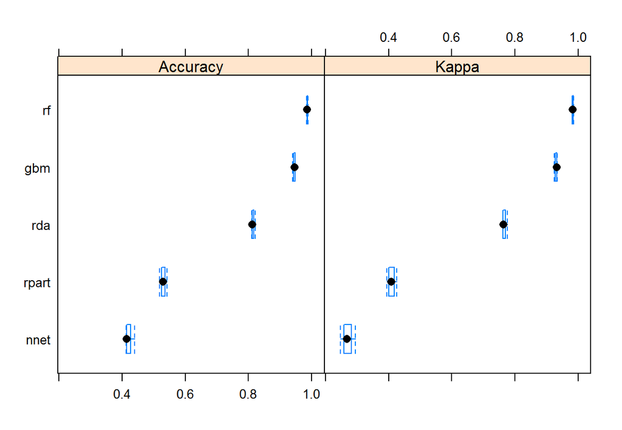

```r
bwplot(resamples(list(rpart = rpartFit, gbm = gbmFit, nnet = nnetFit, rda = rdaFit, rf = rfFit)))
```

## Results

Once selected the best model, we apply this model to our original testing data set to obtain the final predictions.

```r
predFinal <- predict(rfFit, newdata = testingSet)
predFinal
```

```
##  [1] B A B A A E D B A A B C B A E E A B B B
## Levels: A B C D E
```